# Assign3

```python
import pandas as pd
import numpy as np
dataset = pd.read_csv('data.csv')
#print(dataset.head())

X = dataset.iloc[:,:-1].values
y = dataset.iloc[:,11].values
print(X)
```

```
[[ 2 13 44 ...  0  0  2]
 [ 3 11 33 ...  0  0  6]
 [ 3 68 52 ...  0  1  2]
 ...
 [ 3 67 59 ...  0  1  1]
 [ 3 70 49 ...  0  1  1]
 [ 3 50 36 ...  0  1  3]]
```

1) Display the number of instances for each class. That is, you should write code to find out how many instances you have for class 1, class 2, class 3, and class 4. (No loops)

```python
print("class 1: ", np.count_nonzero(y == 1))
print("class 2: ", np.count_nonzero(y == 2))
print("class 3: ", np.count_nonzero(y == 3))
print("class 4: ", np.count_nonzero(y == 4))
```

```
class 1:  266
class 2:  217
class 3:  281
class 4:  236
```

2) Perform one hot encoding on Column 1 (i.e. region) and drop the extra dummy variable.

```python
from sklearn.compose import make_column_transformer
from sklearn.preprocessing import OneHotEncoder
col_trans = make_column_transformer((OneHotEncoder(), [0]), remainder='passthrough')
X = col_trans.fit_transform(X)

print(X[0])

#Drop exta variable
X=X[:,1:]
print(X[0])
```

```
[ 0.  1.  0. 13. 44.  1.  9. 64.  4.  5.  0.  0.  2.]
[ 1.  0. 13. 44.  1.  9. 64.  4.  5.  0.  0.  2.]
```

3) Create histograms of columns age and income to visually explore their distributions.

[figure not shown]

[figure not shown]

```python
import matplotlib.pyplot as plt
plt.hist(X[3],bins='auto')
plt.title('Age Distribution')
plt.show()

plt.hist(X[6],bins='auto')
plt.title('Income Distribution')
plt.show()
```

4) Split the dataset into training (70%) and testing set (30%). Perform normalization of the data using standardization.

```python
from sklearn.model_selection import train_test_split
X_train, X_test, y_train, y_test = train_test_split(X,y,test_size=0.3,random_state=0)

from sklearn.preprocessing import StandardScaler
sc_X = StandardScaler()
X_train = sc_X.fit_transform(X_train)
X_test = sc_X.transform(X_test)

print(X_train)
```

```
[[ 1.39326109 -0.71317648 -1.00191124 ... -0.20412415  0.97182532
  -0.94935624]
 [-0.71774056 -0.71317648 -0.90844314 ... -0.20412415 -1.02899151
   1.14261449]
 [-0.71774056  1.40217748  0.8674507  ... -0.20412415  0.97182532
  -0.94935624]
 ...
 [ 1.39326109 -0.71317648 -0.39436861 ... -0.20412415  0.97182532
   1.14261449]
 [ 1.39326109 -0.71317648  0.72724856 ... -0.20412415 -1.02899151
  -0.25203266]
 [-0.71774056  1.40217748  1.66192953 ... -0.20412415  0.97182532
  -0.25203266]]
```

5) Model 1: Fit a logistic regression model. What is the testing misclassification rate you get?

```python
from sklearn.linear_model import LogisticRegression
from sklearn.metrics import accuracy_score
LRObj = LogisticRegression(random_state=0)
LRObj.fit(X_train, y_train)

#Making predictions on the Test Set
y_pred_LR = LRObj.predict(X_test)

#What is the testing misclassification rate you get
from sklearn.metrics import confusion_matrix
print(confusion_matrix(y_test, y_pred_LR))
print("Misclassification Rate: ", 1-accuracy_score(y_test, y_pred_LR))
```

```
[[46  7 31 11]
 [ 9 17 17 20]
 [21 17 35  8]
 [ 9 20  9 23]]
Misclassification Rate:  0.5966666666666667
```

6) Model 2: We will now fit k-NN. However for k-NN you need to specify the value for k. In order to figure that out, run k-NN in a loop with different values of k (starting from k=5) and compute the testing misclassification rate. Plot a chart with k on X-axis and testing error on the Y-axis. What is the lowest value of testing error and corresponding value of k?

```python
#run k-NN in a loop with different values of k (starting from k=5) and compute the testing misclassification rate
from sklearn.neighbors import KNeighborsClassifier
smallest = 1
for k in range(5, X_train.shape[0]):
    kNNObj = KNeighborsClassifier(n_neighbors=k)
    kNNObj.fit(X_train, y_train)
    misclass =(1-kNNObj.score(X_test,y_test))
    if misclass < smallest:
        smallest=misclass
        bestk = k

print("The best value for k is " , bestk)
print("with a misclassification rate of " ,smallest)

#Prediction
kNNObj = KNeighborsClassifier(n_neighbors=bestk)
kNNObj.fit(X_train, y_train)
y_pred_knn= kNNObj.predict(X_test)
#Confusion Matrix
print(confusion_matrix(y_test, y_pred_knn))
```

```
The best value for k is  220
with a misclassification rate of  0.5800000000000001
[[52  2 37  4]
 [13  8 23 19]
 [25  6 44  6]
 [11  7 21 22]]
```

7) Model 3: Fit SVM model with different kernels. Which kernel gives the least testing error?

```python
from sklearn.svm import SVC

svcObj_rbf = SVC(kernel='rbf')
svcObj_rbf.fit(X_train, y_train)
print("Misclassification Rate rbf: ", 1-svcObj_rbf.score(X_test,y_test))

svcObj_lin = SVC(kernel='linear')
svcObj_lin.fit(X_train, y_train)
print("Misclassification Rate linear: ", 1-svcObj_lin.score(X_test,y_test))

svcObj_sig = SVC(kernel='sigmoid')
svcObj_sig.fit(X_train, y_train)
print("Misclassification Rate sigmoid: ", 1-svcObj_sig.score(X_test,y_test))

svcObj_poly = SVC(kernel="poly")
svcObj_poly.fit(X_train, y_train)
print("Misclassification Rate poly: ", 1-svcObj_poly.score(X_test,y_test))


##Looks like linear gives the least testing error on this dataset
```

```
Misclassification Rate rbf:  0.64
Misclassification Rate linear:  0.5966666666666667
Misclassification Rate sigmoid:  0.6066666666666667
Misclassification Rate poly:  0.6433333333333333
```

8) Model 4: Fit Naïve Bayes model. What is the testing error you get?

```python
from sklearn.naive_bayes import GaussianNB
NBObj = GaussianNB()
NBObj.fit(X_train, y_train)

#Making predictions on the Test Set
y_pred_NB = NBObj.predict(X_test)

#What is the testing misclassification rate you get
print(confusion_matrix(y_test, y_pred_NB))

print("Misclassification Rate: ", 1-accuracy_score(y_test, y_pred_NB))
```

```
[[73  7 15  0]
 [39 10 10  4]
 [42 13 23  3]
 [30 16  5 10]]
Misclassification Rate:  0.6133333333333333
```

9) Model 5: Fit Random Forest model. For Random Forest, you need to specify the number of trees (n_estimators). In order to figure that out, run Random Forest in a loop with different values of n_estimators (starting from 10) and compute the testing misclassification rate. Plot a chart with n_estimators on X-axis and testing error on the Y-axis. What is the lowest value of testing error and corresponding value of n_estimators?

```
The smallest misclassication error is:  0.6133333333333333
Corresponding to n_estimators =  12
```

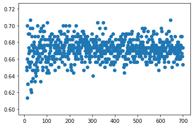

```python
from sklearn.ensemble import RandomForestClassifier
est = []
err = []
for n in range(10, X_train.shape[0]):
    RFObj = RandomForestClassifier(n_estimators = n, criterion='entropy')
    RFObj.fit(X_train,y_train)
    est.append(n)
    err.append(1-RFObj.score(X_test,y_test))


print("The smallest misclassication error is: ", min(err))
print("Corresponding to n_estimators = ", est[err.index(min(err))])

# Plot
plt.scatter(est,err)
plt.show()
```

10) Predicting with Ensemble: Now that you have built 5 models. Loop over the testing set. For every test instance, have each of the models predict the class label. Eventual class predicted will be based on a majority vote of the 5 models. What is the testing misclassification rate you get with the ensemble model?

```python
from statistics import mode
from scipy import stats
y_pred_ens = []
for x in range(0, X_test.shape[0]):
    l=LRObj.predict(X_test[[x]])
    k=kNNObj.predict(X_test[[x]])
    s=svcObj_lin.predict(X_test[[x]])
    n=NBObj.predict(X_test[[x]])
    r=RFObj.predict(X_test[[x]])
    array = np.concatenate((l,k,s,n,r))
    y_pred_ens.append(int(stats.mode(array)[0]))

print(confusion_matrix(y_test, y_pred_ens))
print("Misclassification Rate: ", 1-accuracy_score(y_test, y_pred_ens))
```

```
[[54  7 27  7]
 [12 17 20 14]
 [22 15 36  8]
 [13 20 10 18]]
Misclassification Rate:  0.5833333333333333
```